# Association Rules

##### The association rule algorithm enable us to **find interesting relations within multiple databases to answer questions** such as: which products tend to be purchased together, or who buys what? This algorithm is also used in medical diagnosis, bio-medical, census data, fraud detection in web, CRM of credit card business, recommendation system and content optimisation.

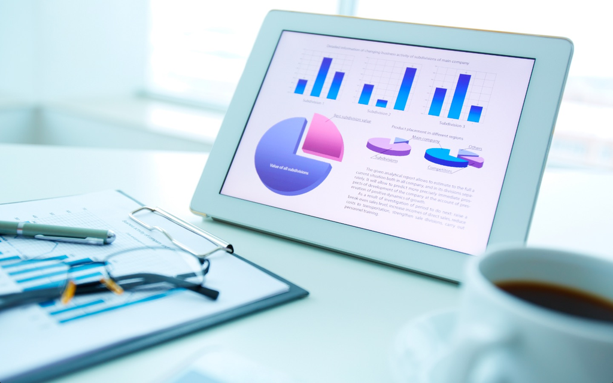

Find me on twitter: LudoBenistant

# 1 Introduction

## 1.1 Association rule

This unsupervised learning method enable us to **find interesting relation within multiple databases to answer questions such as: which products tend to be purchased together, or who buys what?…**

Here we take an example where a company want to see **which customer answered to our latest marketing campaign** to compare and improve these campaigns in the future.

## 1.2 Solution

We will use the association rule algorithm called **apriori** from the **arules packages** to evaluate our marketing campaign and see who tends to respond to our latest offer. Like any association rule algorithm it usually split up into two separate steps:

- A minimum support threshold is applied to find all frequent item-sets in a database.
- A minimum confidence constraint is applied to these frequent item-sets in order to form rules.

Agrawal & Srikant have proposed a well-known approach which is the Apriori Algorithm. This approach is an **iterative process and each iteration has two steps:**

- Step 1: To generate a set of candidate item sets.
- Step 2: To prune all the disqualified candidates (i.e. all infrequent item sets).

# 2 Data exploration

## 2.1 The data quality report

### 2.1.1 Numeric variables

```
##   Customer_id answered age sex children distance pets
## 1      183010        1   2   1        1        1    1
## 2      144610        1   2   1        1        1    1
## 3      164930        1   2   1        1        1    1
## 4      141340        1   1   1        1        1    1
## 5       13610        1   1   1        1        1    0
## 6       98790        1   2   1        1        1    1
```

```
##   Customer_id        answered           age             sex
##  Min.   :    80   Min.   :0.0000   Min.   :1.000   Min.   :0.000
##  1st Qu.:104602   1st Qu.:0.0000   1st Qu.:1.000   1st Qu.:0.000
##  Median :156875   Median :0.0000   Median :2.000   Median :0.000
##  Mean   :151336   Mean   :0.1214   Mean   :1.924   Mean   :0.455
##  3rd Qu.:204758   3rd Qu.:0.0000   3rd Qu.:3.000   3rd Qu.:1.000
##  Max.   :264200   Max.   :1.0000   Max.   :3.000   Max.   :1.000
##     children         distance          pets
##  Min.   :0.0000   Min.   :1.000   Min.   :0.0000
##  1st Qu.:0.0000   1st Qu.:2.000   1st Qu.:0.0000
##  Median :0.0000   Median :3.000   Median :0.0000
##  Mean   :0.3639   Mean   :2.564   Mean   :0.3692
##  3rd Qu.:1.0000   3rd Qu.:3.000   3rd Qu.:1.0000
##  Max.   :1.0000   Max.   :3.000   Max.   :1.0000
```

### 2.1.2 Factor variables

```
##   Customer_id answered         age   sex children distance pets
## 1      183010      yes middle-aged woman      yes     near  yes
## 2      144610      yes middle-aged woman      yes     near  yes
## 3      164930      yes middle-aged woman      yes     near  yes
## 4      141340      yes       young woman      yes     near  yes
## 5       13610      yes       young woman      yes     near   no
## 6       98790      yes middle-aged woman      yes     near  yes
```

```
##   Customer_id     answered             age          sex       children
##  Min.   :    80   no :13409   young      :5264   man  :8318   no :9708
##  1st Qu.:104602   yes: 1853   middle-aged:5888   woman:6944   yes:5554
##  Median :156875               elderly    :4110
##  Mean   :151336
##  3rd Qu.:204758
##  Max.   :264200
##       distance     pets
##  near     : 130   no :9628
##  in-middle:6393   yes:5634
##  far      :8739
##
##
##
```

# 3 Modeling

## 3.1 Association Rules

Here we are using the apriori algorithm to create our association rules model. We want to know **who is answering to our marketing campaign.** Of course, this is a simple example, but we can imagine this algorithm working with many more variables and evaluating different marketing activities launched in parallel.

### 3.1.1 Apriori Algorithm

The Apriori algorithm takes a bottom-up iterative approach to uncovering the frequent item sets by first determining all the possible items and then identifying which among them are frequent. We will use **the apriori() function from the arule package to implements the Apriori algorithm and create frequent item sets.**

```r
library(arules)
attach(Customer_info)
# select only the relevant variables
Customer_info <- Customer_info %>% select(answered:pets)

# precise settings
rules <- apriori(Customer_info, parameter = list(minlen=2, supp=0.005, conf=0.8), appearance = list(rhs=c("answered=no", "answered=yes"), default="lhs"), control = list(verbose=F))
rules.sorted <- sort(rules, by="lift")
inspect(head(sort(rules.sorted, by="support"), 10))
```

```
##    lhs                           rhs           support   confidence
## 9  {children=no}              => {answered=no} 0.5995938 0.9426246
## 8  {pets=no}                  => {answered=no} 0.5627048 0.8919817
## 7  {distance=far}             => {answered=no} 0.5419342 0.9464470
## 6  {sex=man}                  => {answered=no} 0.5147425 0.9444578
## 47 {sex=man,children=no}      => {answered=no} 0.3990958 0.9677471
## 50 {children=no,pets=no}      => {answered=no} 0.3857293 0.9339997
## 49 {children=no,distance=far} => {answered=no} 0.3757044 0.9697277
## 48 {distance=far,pets=no}     => {answered=no} 0.3522474 0.9459792
## 5  {distance=in-middle}       => {answered=no} 0.3360634 0.8022837
## 46 {sex=man,pets=no}          => {answered=no} 0.3244005 0.9334465
##    lift
## 9  1.072887
## 8  1.015245
## 7  1.077237
## 6  1.074973
## 47 1.101481
## 50 1.063070
## 49 1.103735
## 48 1.076705
## 5  0.913152
## 46 1.062440
```

### 3.1.2 Pruning Redundant Rules

```r
# find redundant rules
subset.matrix <- is.subset(rules.sorted, rules.sorted)
subset.matrix[lower.tri(subset.matrix, diag=T)] <- NA
redundant <- colSums(subset.matrix, na.rm=T) >= 1
head(which(redundant))
```

```
##           {answered=yes,age=middle-aged,children=yes,distance=near}
##                                                                   3
##                 {answered=yes,sex=woman,children=yes,distance=near}
##                                                                   4
##              {answered=yes,age=middle-aged,sex=woman,distance=near}
##                                                                   5
## {answered=yes,age=middle-aged,sex=woman,children=yes,distance=near}
##                                                                   6
##                           {answered=yes,children=yes,distance=near}
##                                                                   9
##             {answered=no,age=elderly,sex=man,children=yes,pets=yes}
##                                                                  20
```

## 3.2 Visualizing The Rules

In order to select interesting rules from the set of all possible rules, **constraints on various measures of significance and interest are used.** The best-known constraints are minimum thresholds on support and confidence.

- **Support** is an indication of how frequently the item-set appears in the database.
- **Confidence** is an indication of how often the rule has been found to be true.

${\displaystyle \mathrm {conf} (X\Rightarrow Y)=\mathrm {supp} (X\cup Y)/\mathrm {supp} (X)} {\mathrm {conf}}(X\Rightarrow Y)={\mathrm {supp}}(X\cup Y)/{\mathrm {supp}}(X).$

- The **lift** of a rule is defined the ratio of the observed support to that expected if X and Y were independent.

${\displaystyle \mathrm {lift} (X\Rightarrow Y)={\frac {\mathrm {supp} (X\cup Y)}{\mathrm {supp} (X)\times \mathrm {supp} (Y)}}} {\mathrm {lift}}(X\Rightarrow Y)={\frac {{\mathrm {supp}}(X\cup Y)}{{\mathrm {supp}}(X)\times {\mathrm {supp}}(Y)}}$

*We use the arulesViz library.

### 3.2.1 Scatter plot

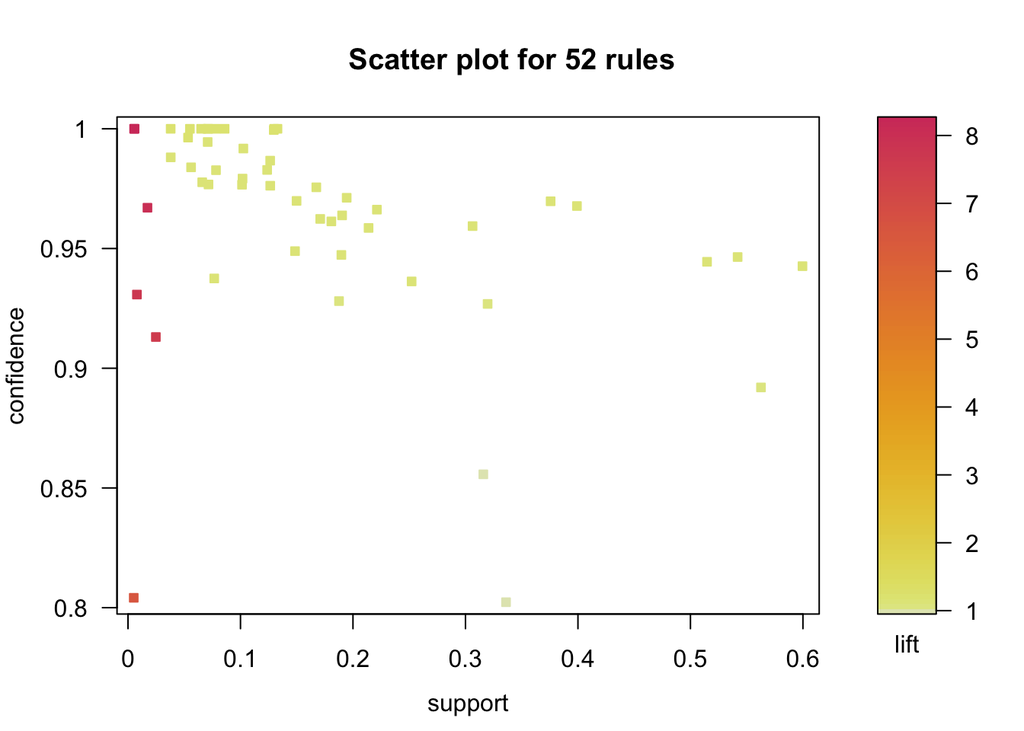

```r
## install.packages(arules , scatterplot3d, vcd, seriation, igraph,"grid","cluster","TSP","gclus", "colorspace")
## install.packages("arulesViz")

library(arulesViz)
# remove redondant rules.
rules.pruned <- rules.sorted[!redundant]
plot(rules.pruned)
```

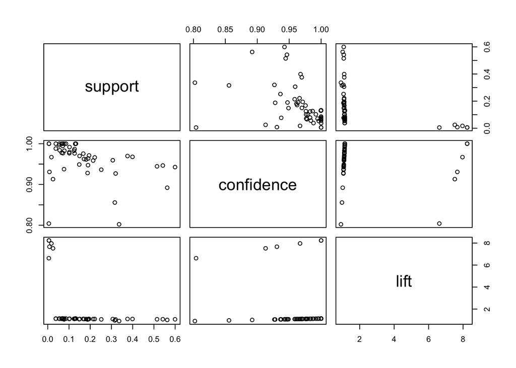

```r
plot(rules.pruned@quality)
```

### 3.2.2 Graphs

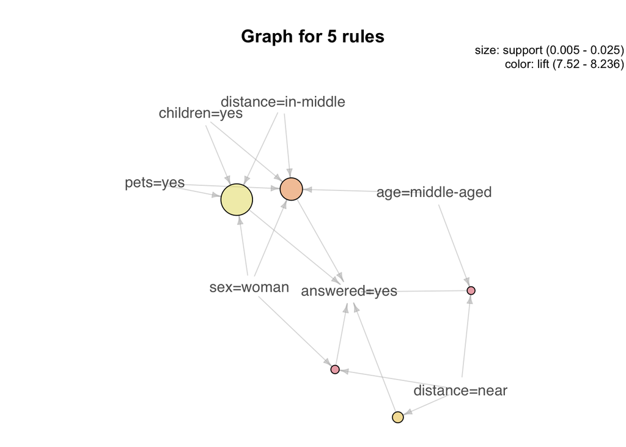

```r
# example with only 5
highliftrules <- head(sort(rules.pruned, by = "lift"), 5)
plot(highliftrules, method = "graph", control = list(type="items"))
```

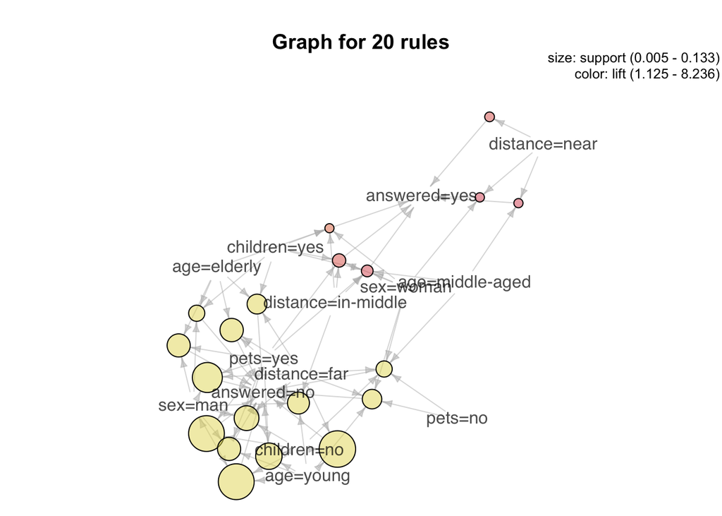

```r
# now 20
highliftrules <- head(sort(rules.pruned, by = "lift"), 20)
plot(highliftrules, method = "graph", control = list(type="items"))
```

# 4 Conclusion

From this simple example, we can see that the people who answer to our marketing campaign are mainly **woman of middle age, with children and/or pets and who leave not far from the store.** Furthermore the scatter plot present how much robust these rules are.

**Methods to Improve Apriori’s Efficiency:**

• Hash-based itemset counting: A k-itemset whose corresponding hashing bucket count is below the threshold cannot be frequent.

• Transaction reduction: A transaction that does not contain any frequent k-itemset is useless in subsequent scans.

• Partitioning: Any itemset that is potentially frequent in DB must be frequent in at least one of the partitions of DB.

• Sampling: mining on a subset of given data, lower support threshold + a method to determine the completeness.

• Dynamic itemset counting: add new candidate itemsets only when all of their subsets are estimated to be frequent.

Source: Data Science and Big Data Analytics: Discovering, Analyzing, Visualizing and Presenting Data Hardcover – 17 Mar 2015 by EMC Education Services (Editor)

Last updated on 12/2015